# Exercises Data Science with R

Thomas Kirschstein

# Chapter 1

There are quite a lot standard basic mathematical functions. Try to google for R cheat sheets if you are interested in a comprehensive overview.

```r
3^2     #1
```

```
## [1] 9
```

```r
sqrt(9) #2
```

```
## [1] 3
```

```r
9^.5
```

```
## [1] 3
```

```r
pi^2    #3
```

```
## [1] 9.869604
```

```r
(abs(3^2-4^2))^.5 #4
```

```
## [1] 2.645751
```

```r
log(exp(4), base = exp(1)) #5
```

```
## [1] 4
```

```r
log(exp(4))
```

```
## [1] 4
```

```r
log(100, base = 10) #6
```

```
## [1] 2
```

```r
log10(100)
```

```
## [1] 2
```

```r
factorial(8) #7
```

```
## [1] 40320
```

```r
exp(factorial(3)) #8
```

```
## [1] 403.4288
```

# Chapter 2

The chapter intends to focus on writing simple functions in R.

1. Formulate the EOQ formula in R

```r
cost_eoq_fun <- function(q, d, co, cl) {
  # returns total cost per period
  # d...demand
  # q...lot size
  # co...ordering cost
  # cl...stock holding cost
  ((1/2)*cl*q)+((d/q)*co)
}

# test cost function
cost_eoq_fun(d=100, q=20, cl = .1, co = 50)
```

```
## [1] 251
```

```r
eoq_fun <- function(co, d, cl) {
  # return optimal lot size
  # d...demand
  # co...ordering cost
  # cl...stock holding cost
  sqrt((2*co*d)/cl)
}
# optimal lot size
q.star <-  eoq_fun(d = 100, cl = .1, co = 50)
# optimal cost
cost_eoq_fun(d=100, q=q.star, cl = .1, co = 50)
```

```
## [1] 31.62278
```

2. Derive a function for calculating weighted Euclidean distance between two points.

```r
weuc_d2_func <- function(x,y,w) {
  # calculates weighted Euclidean distance between x and y
  # y,x...vectors
  # w.. weight vector
  sqrt(sum(w*(x-y)^2))
}
# test distacne function
weuc_d2_func(x = c(1,2,3), y= c(3,2,1), w=c(1,1,1) )
```

```
## [1] 2.828427
```

```r
# result should be sqrt(8)
```

3. Alter your EOQ function by checking whether all arguments are supplied and stop execution while displaying a error message. -> postponed
4. Formulate a function for the Geometric Poisson density distribution.

```r
geom_pois_dens_fun <- function(n, lambda, theta){
  # calculates density value of geometric Poisson distribution
  # n...integer, demand/successes, theta,lambda..parameters
  k.vec <- 1:n
  sum(exp(-lambda)*lambda^k.vec/factorial(k.vec)*(1-theta)^(n-k.vec)*choose(n-1, k.vec-1))
}
# test function
geom_pois_dens_fun(n=3, lambda=.5, theta = 2)
```

```
## [1] 0.1642687
```

# Chapter 3

Basics on data types and data manipulation

1. Calculate the outer product of two vectors (without outer())

```r
x <- 1:5
y <- 10:6
as.matrix(x) %*% t(as.matrix(y))
```

```
##      [,1] [,2] [,3] [,4] [,5]
## [1,]   10    9    8    7    6
## [2,]   20   18   16   14   12
## [3,]   30   27   24   21   18
## [4,]   40   36   32   28   24
## [5,]   50   45   40   35   30
```

```r
outer(x,y)
```

```
##      [,1] [,2] [,3] [,4] [,5]
## [1,]   10    9    8    7    6
## [2,]   20   18   16   14   12
## [3,]   30   27   24   21   18
## [4,]   40   36   32   28   24
## [5,]   50   45   40   35   30
```

2. Define a function that calculates the trace of a matrix.

```r
trace_func <- function(z){
  # calculates trace of z
  # z...matrix
  sum(diag(z))
}
tmp <- rnorm(9)
A <- matrix(tmp, ncol=3, byrow = T)
trace_func(A)
```

```
## [1] 4.274796
```

3.Create a vector containing the first 100 Fibonacci numbers. Most commonly, the Fibonacci numbers are defined recursively by $F_n=F_{n-1}+F_{n-2}$ whereby $F_0 =0$ and $F_1=1$. However, there is also an explicit formulation: $F_n = \sum_{k=0}^{\lfloor \frac{n-1}{2} \rfloor} \binom{n-k-1}{k}$ (ceck [here](https://en.wikipedia.org/wiki/Fibonacci_number#Mathematics))

```r
fib_num_fun <- function(n){
  # calculate nth Fibonacci number
  # n...number
  k.vec <- 0:floor((n-1)/2)
  sum(choose(n-k.vec-1, k.vec))
}
# vectorize fib_num_fun such that it accepts input vectors
vfib_num_fun <- Vectorize(fib_num_fun)
# doesn't work
fib_num_fun(1:10)
# works
vfib_num_fun(1:100)
```

```
##   [1] 1.000000e+00 1.000000e+00 2.000000e+00 3.000000e+00 5.000000e+00
##   [6] 8.000000e+00 1.300000e+01 2.100000e+01 3.400000e+01 5.500000e+01
##  [11] 8.900000e+01 1.440000e+02 2.330000e+02 3.770000e+02 6.100000e+02
##  [16] 9.870000e+02 1.597000e+03 2.584000e+03 4.181000e+03 6.765000e+03
##  [21] 1.094600e+04 1.771100e+04 2.865700e+04 4.636800e+04 7.502500e+04
##  [26] 1.213930e+05 1.964180e+05 3.178110e+05 5.142290e+05 8.320400e+05
##  [31] 1.346269e+06 2.178309e+06 3.524578e+06 5.702887e+06 9.227465e+06
##  [36] 1.493035e+07 2.415782e+07 3.908817e+07 6.324599e+07 1.023342e+08
##  [41] 1.655801e+08 2.679143e+08 4.334944e+08 7.014087e+08 1.134903e+09
##  [46] 1.836312e+09 2.971215e+09 4.807527e+09 7.778742e+09 1.258627e+10
##  [51] 2.036501e+10 3.295128e+10 5.331629e+10 8.626757e+10 1.395839e+11
##  [56] 2.258514e+11 3.654353e+11 5.912867e+11 9.567220e+11 1.548009e+12
##  [61] 2.504731e+12 4.052740e+12 6.557470e+12 1.061021e+13 1.716768e+13
##  [66] 2.777789e+13 4.494557e+13 7.272346e+13 1.176690e+14 1.903925e+14
##  [71] 3.080615e+14 4.984540e+14 8.065155e+14 1.304970e+15 2.111485e+15
##  [76] 3.416455e+15 5.527940e+15 8.944394e+15 1.447233e+16 2.341673e+16
##  [81] 3.788906e+16 6.130579e+16 9.919485e+16 1.605006e+17 2.596955e+17
##  [86] 4.201961e+17 6.798916e+17 1.100088e+18 1.779979e+18 2.880067e+18
##  [91] 4.660047e+18 7.540114e+18 1.220016e+19 1.974027e+19 3.194043e+19
##  [96] 5.168071e+19 8.362114e+19 1.353019e+20 2.189230e+20 3.542248e+20
```

```r
pas <- outer(1:10, 1:10, choose)
```

5. Preference matrices in the Analytical Hierachy Process (AHP) show a form of (inverted) symmetry. How can you check this in R?

The AHP method requires for a matrix $A=\{a_{ij}|i,j=1,...,n\}$ that $a_{i,j} = \frac{1}{a_{j,i}}$. Thereby, diagonal elements are always 1 (i.e., $a_{ii} = 1$)

```r
# create 3x3 matrix
A <- matrix(sample(1:10 , 9), ncol=3)
# diagonals to 1
diag(A) <- 1
# checks matrix elementwise
A == t(1/A) # -> problem double counting of elements
```

```
##       [,1]  [,2]  [,3]
## [1,]  TRUE FALSE FALSE
## [2,] FALSE  TRUE FALSE
## [3,] FALSE FALSE  TRUE
```

```r
# Alternative: compare just elements of triangle sub-matrices
A[lower.tri(A)] == 1/A[upper.tri(A)]
```

```
## [1] FALSE FALSE FALSE
```

6. Calculate the synthesis of an AHP preference matrix

The synthesis is calculated in two steps: (a) normalizing $A$ by dividing with column sums (b) calculate row means of normalized matrix

```r
# convert A (chunk before) into a consistent matrix
A[lower.tri(A)] <- 1/A[upper.tri(A)]
# step (a) of synthesis
dev <- colSums(A) # calculate colSums
A.prime <- t(t(A) / dev) # Alternative a: using that R divides columnwise
A.prime <- A %*% diag(1 / dev) # Alternative b: use matrix calculation
# step (b) of synthesis
rowMeans(A.prime)
```

```
## [1] 0.68558072 0.25467907 0.05974021
```

# Chapter 4

1. Construct a list with 100 entries. Afterwards, display only entries with odd indices.

```r
x <- sample(x = 1:100, size = 100)
l1 <- as.list(x)
l1.odd <- l1[1:100 %% 2 == 1]
l1.odd <- l1[seq(1, 100, by = 2)]
```

2. Construct a tibble or data frame consisting of 100 columns and 1 row. Extract only every 3rd column.

```r
z <- matrix(sample(x = 1:1000, size = 100), nrow=1)
z <- as.data.frame(z)
z.sub <- z[, col(z) %% 3 == 0]
```

3. Construct a matrix of size $6 \times 6$ and fill it by sampling numbers between 1 and 100. Retain indices of all entries $\leq 50$.

```r
A <- matrix(sample(x = 1:100, 36), ncol = 6)
which(A <= 50)
```

```
##  [1]  1  2  3  5  8 11 14 15 16 17 18 19 22 23 27 28 30 36
```

4. Formulate a function for calculating the moving average over a vector.

```r
ma_fun <- function(x, n){
  # calculates moving average
  # x...vector to be averaged, n...time window width
  cx <- c(0,cumsum(x))
  (cx[(n+1):length(cx)] - cx[1:(length(cx) - n)]) / n
}
# test function
ma_fun(x = 1:10 , n=4)
```

```
## [1] 2.5 3.5 4.5 5.5 6.5 7.5 8.5
```

# Chapter 5

1. Sample 100 observations in the range $[-3,3]$ from the follwing model and plot the sample:
   $$y = \sin(3 \cdot x^2 - 4) \cdot x + 0.5 \cdot x + \epsilon$$
   whereby $\epsilon \sim N(0,0.5)$. Can you estimate a regression function?

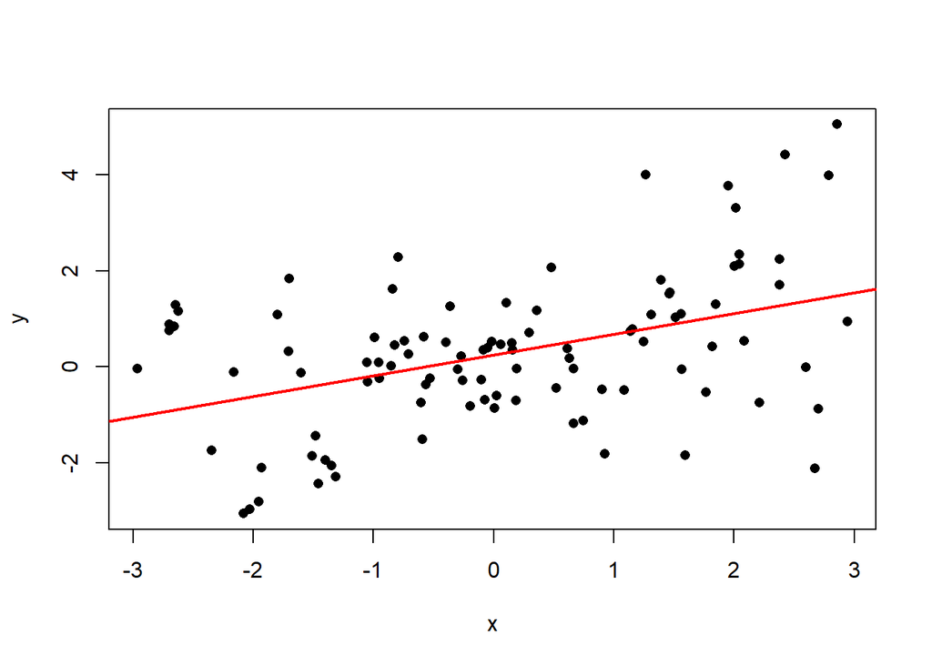

```r
n <- 100                                # number of points to plot
x <- runif(n, min=-3, max=3)            # 100 x coordinates
y <- sin(3 * x^2 - 4) * x + 0.5 * x + rnorm(n, mean = 0, sd = sqrt(.5))
plot(x[order(x)], y[order(x)], xlab ="x", ylab = "y", pch = 16)
lin.reg <- lm(y~x)                      # fit a linear regression model
abline(lin.reg, col = "red", lwd =2)    # ... and plot the regression line
```

2. Plot the EOQ model in an appropriate range.

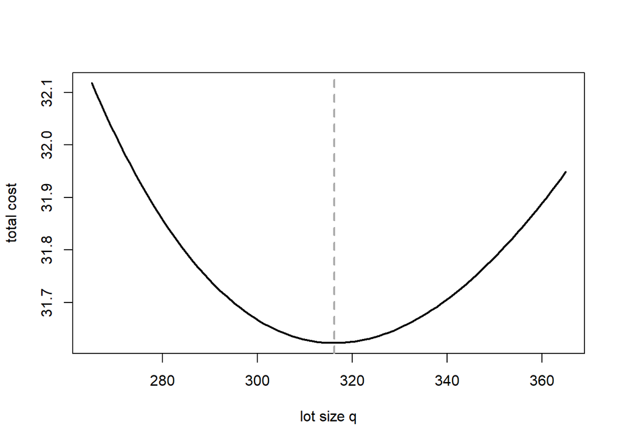

```r
q.vec <- seq(265, 365, length.out = 100)
y.vec <- cost_eoq_fun(q = q.vec , d = 100, cl = .1, co = 50)
plot(q.vec, y.vec, xlab ="lot size q", ylab = "total cost", type = "l", lwd =2)
abline(v = eoq_fun(d = 100, cl = .1, co = 50), col="darkgrey", lwd=2, lty=2)
```

3. Plot the newsvendor model in an appropriate range.

The total cost in the normal newsvendor model is given by
$$Z(q) = \left(c_u + c_o \right) \cdot \sigma \cdot \left( \varphi(q') + q' \cdot \Phi(q') \right) - c_u \cdot (q-\mu)$$
with $q' = \frac{q-\mu}{\sigma}$

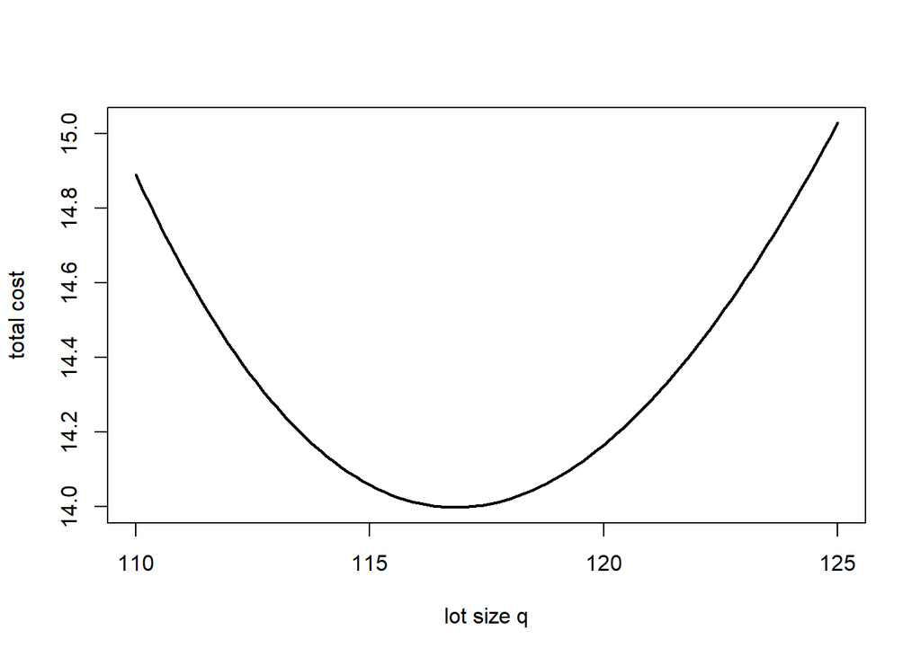

```r
newsven_obj_fun <- function(x, cu, co, mu, sigma){
      q.prime <- (x-mu)/sigma
         (cu + co) * sigma * (dnorm(q.prime) + q.prime * pnorm(q.prime)) - cu * sigma * q.prime
}
q.vec <- seq(110, 125, length.out = 100)
cost.vec <- newsven_obj_fun(x = q.vec , mu = 100, cu = 2, co = 0.5, sigma = 20)
plot(q.vec, cost.vec, xlab ="lot size q", ylab = "total cost", type = "l", lwd = 2)
```

4. Plot the EOQ model in an appropriate range and add holding cost function and ordering cost function in different colors. Add a legend to the plot.

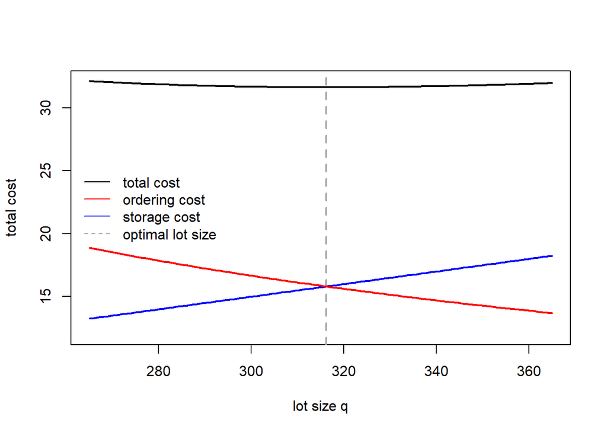

```r
q.vec <- seq(265, 365, length.out = 100)
y.vec <- cost_eoq_fun(q = q.vec , d = 100, cl = .1, co = 50)
plot(q.vec, y.vec, xlab ="lot size q", ylab = "total cost", type = "l", lwd =2, ylim=c(12,max(y.vec)))
abline(v = eoq_fun(d = 100, cl = .1, co = 50), col="darkgrey", lwd=2, lty=2)
lines(x=q.vec, y=(1/2)*.1*q.vec, lwd=2, col="blue")
lines(x=q.vec, y=(100/q.vec)*50, lwd=2, col="red")
legend("left", lty = c(1,1,1,2), col = c("black","red","blue","darkgrey"), legend = c("total cost", "ordering cost", "storage cost", "optimal lot size"), bty="n" )
```

5. Consider the joint economic lot size model. Supplier and customer face setup costs ($c^{sup.}_{set}$ ,$c^{cust.}_{set}$) as well as stock-holding cost rates ($c^{sup.}_{sh}$, $c^{sup.}_{sh}$). The demand rate of the customers is $\lambda$ and production rate of the supplier is $\mu$ (with $\lambda < \mu$). The cost functions of supplier and customer are
   $$C^{cust.}(q) = \frac{\lambda}{q} \cdot c^{cust.}_{set} + c^{cust.}_{sh} \cdot \frac{q}{2}$$
   and
   $$C^{supp.}(q) = \frac{\lambda}{q} \cdot c^{sup.}_{set} + c^{sup.}_{sh} \cdot \frac{q}{2} \cdot \frac{\lambda}{\mu} .$$
   Plot the cost functions of supplier, customer, and the SC (i.e., total cost function) in different colors. Add a legend to the plot.

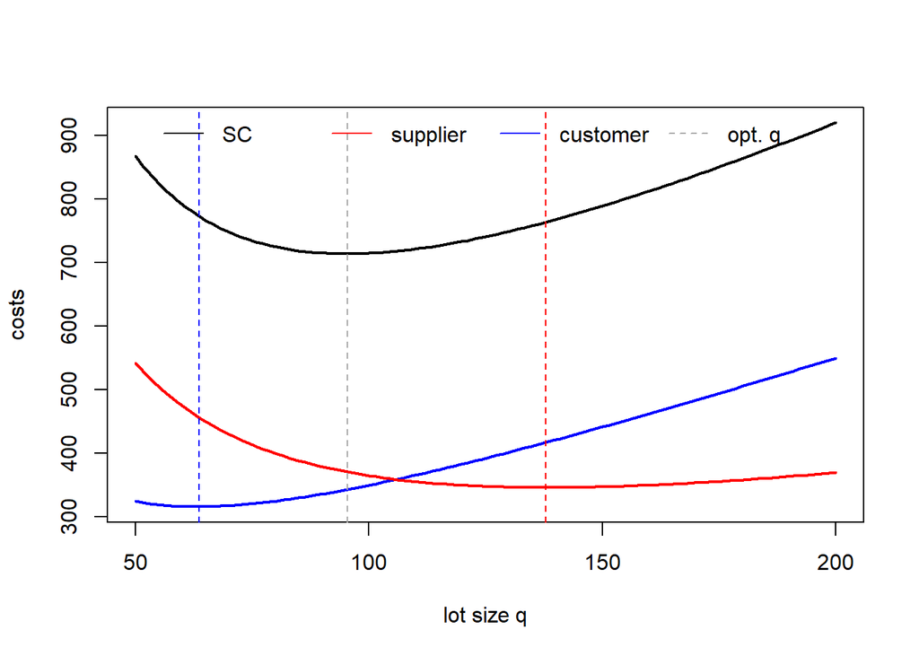

```r
jel_func <- function(q, c.supp.set, c.supp.sh, c.cust.set, c.cust.sh, lambda, mu){
  # costs in joint economic lot sizing model
  if(lambda > mu) stop("infeasible (lambda > mu)") # check feasibility
  c.cust <- lambda/q * c.cust.set  + c.cust.sh *  q/2
  c.supp <-  lambda/q * c.supp.set  + c.supp.sh * q/2 * lambda/mu
  c.sc <- c.supp + c.cust
  return(data.frame(cost.customer = c.cust, cost.supplier = c.supp, cost.sc = c.sc))
}

q.vec <- seq(50, 200, length.out = 100)
y.df <- jel_func(q = q.vec, c.supp.set = 240, c.supp.sh = 4, c.cust.set = 100, c.cust.sh = 5, lambda = 100, mu = 160)

plot(q.vec, y.df$cost.sc, xlab ="lot size q", ylab = "costs", type = "l", lwd = 2, ylim=range(y.df))
lines(x = q.vec, y = y.df$cost.customer, lwd = 2, col = "blue")
lines(x = q.vec, y = y.df$cost.supplier, lwd = 2, col = "red")
abline(v = q.vec[which.min(y.df$cost.customer)], col = "blue", lwd = 1, lty = 2)
abline(v = q.vec[which.min(y.df$cost.supplier)], col = "red", lwd = 1, lty = 2)
abline(v = q.vec[which.min(y.df$cost.sc)], col = "darkgrey", lwd = 1, lty = 2)
legend("top", lty = c(1,1,1,2), col = c("black","red","blue","darkgrey"), legend = c("SC", "supplier", "customer", "opt. q"), bty="n" , horiz = T)
```

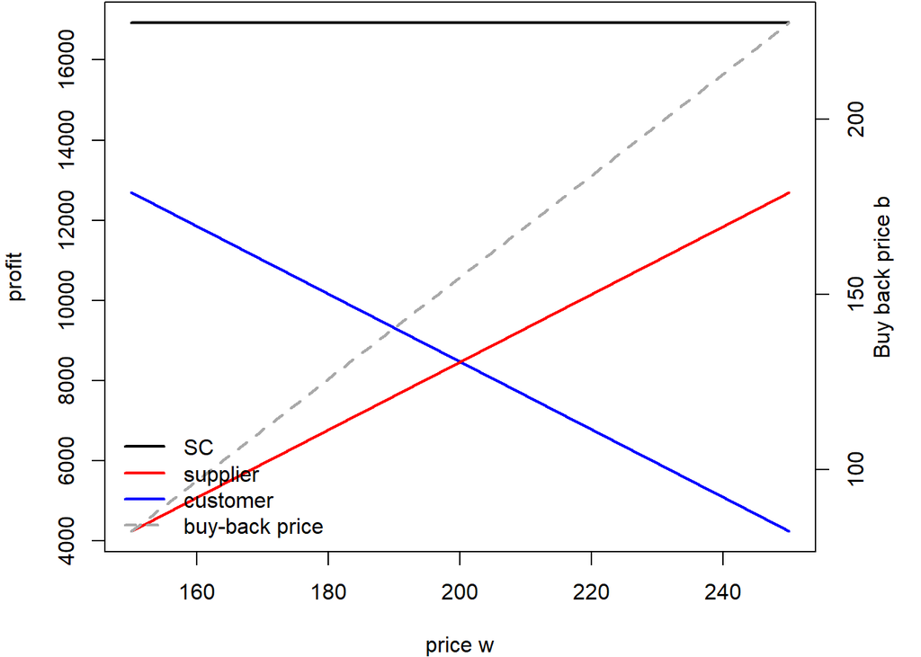

```r
buy_back_func <- function(w, r, c, v, mu, sigma){
  # costs & buy-back price in buy-back model
  crit.rat.sc <- (r-c)/(r-v) # critical ratio SC
  z.sc <- qnorm(crit.rat.sc)
  b <- -(c-v)/(r-c)*r + (r-v)/(r-c)*w
  profit.cust <- (r-w)*mu - (r-b)*dnorm(z.sc)* sigma
  profit.supp <- (w-c)*mu - (b-v)*dnorm(z.sc)* sigma
  return(data.frame(buy.back.price = b, profit.supplier = profit.supp, profit.cust = profit.cust, profit.sc = profit.cust+profit.supp ))
}

w.vec <- seq(150, 250, length.out = 100)
y.df <- buy_back_func(w = w.vec, c = 100, r = 300, v = 10, mu = 100, sigma = 30)
par(mar = c(4, 4, .1, 4) )
plot(w.vec, y.df$profit.sc, xlab ="price w", ylab = "profit", type = "l", lwd = 2, ylim=range(c(y.df$profit.supplier,y.df$profit.cust,y.df$profit.sc)))
lines(x = w.vec, y = y.df$profit.cust, lwd = 2, col = "blue")
lines(x = w.vec, y = y.df$profit.supplier, lwd = 2, col = "red")
# second axis
par(new=T)
# data without axis
plot(w.vec, y.df$buy.back.price, xaxt = "n", yaxt = "n", ylab="", xlab = "", type = "l", lwd = 2, col = "darkgrey", lty = 2)
axis(4) # add axis
mtext( "Buy back price b", side  = 4, line = 2)  # add label
legend("bottomleft", col = c("black","red","blue", "darkgrey"), lty=c(1,1,1,2), lwd=2, legend = c("SC", "supplier", "customer","buy-back price"), bty="n")
```

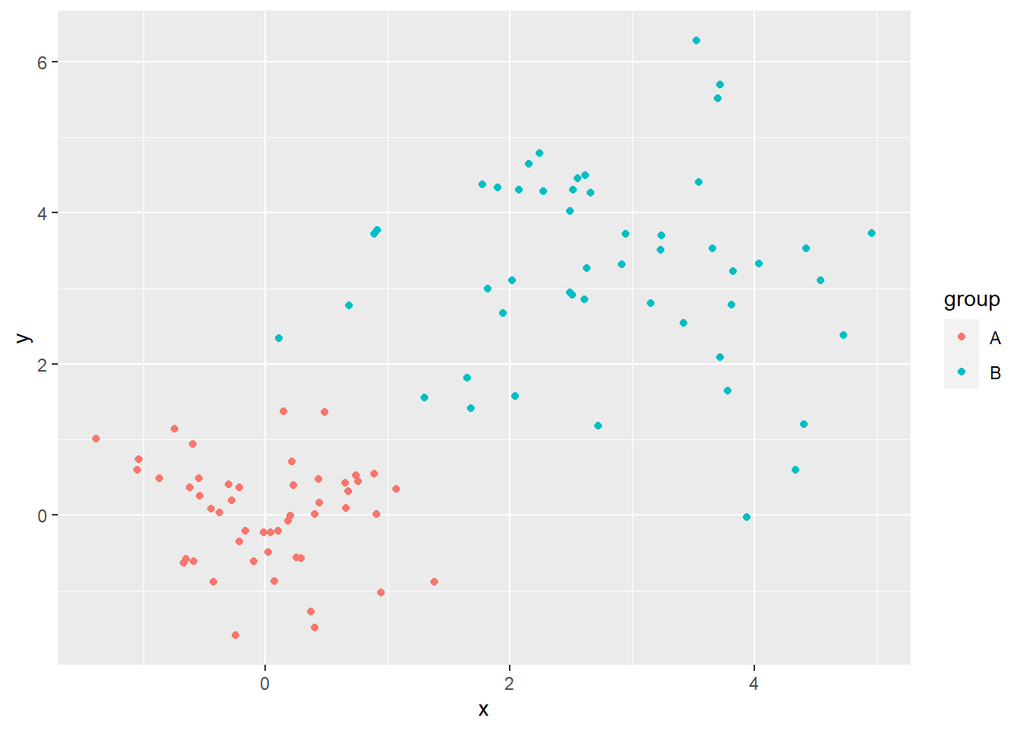

```r
library(tidyverse)
dtib <- tibble(group = c(rep("A",50),rep("B",50)), x.values = c(rnorm(50, mean = 0, sd = sqrt(0.5)), rnorm(50, mean = 3, sd = sqrt(1.5))), y.values = c(rnorm(50, mean = 0, sd = sqrt(0.5)), rnorm(50, mean = 3, sd = sqrt(1.5))))
ggplot(data = dtib, aes(x = x.values, y = y.values, col = group)) + geom_point() + ylab("y") + xlab("x")
```

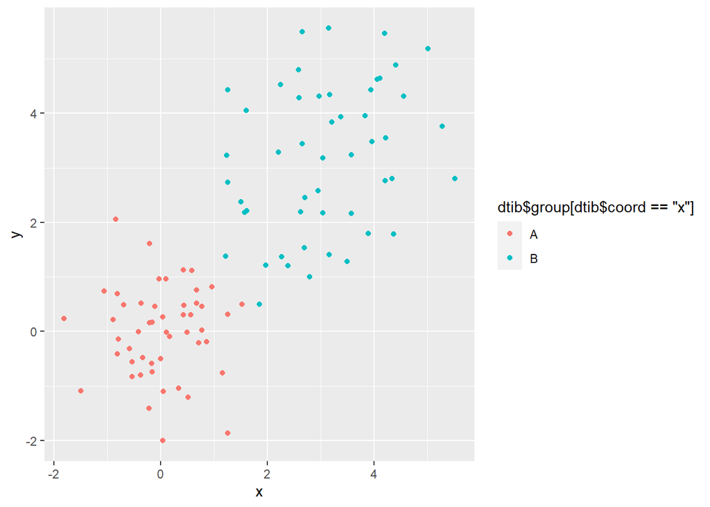

```r
# Alternative (over-tidy)
dtib <- tibble(group = c(rep("A",100),rep("B",100)), coord = rep(c("x","y"), 100), values = c(rnorm(100, mean = 0, sd = sqrt(0.5)), rnorm(100, mean = 3, sd = sqrt(1.5))))
qplot(x = dtib$values[dtib$coord == "x"], y = dtib$values[dtib$coord == "y"], col = dtib$group[dtib$coord == "x"], xlab = "x", ylab="y")
```

8. The data set above is untidy. Create the same data set in a tidy way and recreate the plots above.

-> postponed

9. Alter the structured plot by connecting points by arrows. Test other smoothing methods offered by `geom_smooth`. Add three different smoothing functions to the plot.

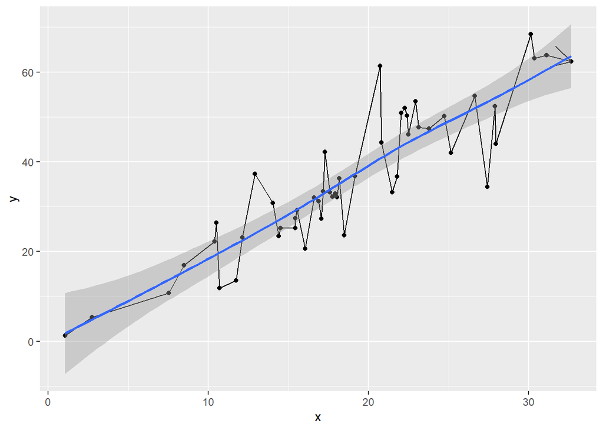

```r
n <- 50                                 # number of points to plot
x <- rnorm(n, 20 , 7)                   # independent x coordinates
y <- 2*x + rnorm(n, 0, x^0.75)          # dependent variable
z <- 0.125*x^2 - x + rnorm(n, 0, 3)     #  dependent variable
dat <- tibble(x = x, y = y, z = z)      # build an untidy tibble with x, y and z
# one large arrow - generalized additive model fit
ggplot(data = dat, mapping = aes(x = x[order(x)], y = y[order(x)]) ) +
  geom_point() +
  geom_path(arrow = arrow()) +
  geom_smooth(method = "gam") +
  labs(x = "x", y = "y")
```

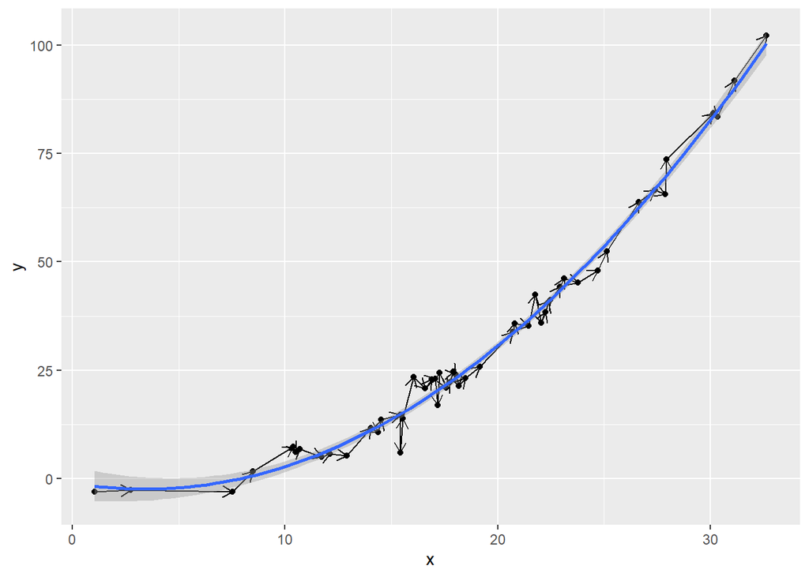

```r
# multiple arrow - generalized linear model with quadratic trend
ggplot(data = dat, mapping = aes(x = x[order(x)], y = z[order(x)]) ) +
  geom_point() +
  geom_segment(aes(xend = dplyr::lead(x[order(x)]), yend = dplyr::lead(z[order(x)])),
               arrow = arrow(type = "open", angle = 30, length = unit(0.1, "inches"))) +
  geom_smooth(method = "glm", formula = y ~ poly(x,2) ) +
  labs(x = "x", y = "y")
```

10. Create a random sample $S = S_1 \cup S_2$ consisting of 50 observations with $S_1 \sim \mathcal{E}(0.5)$ and 20 observations with $S_2 \sim \mathcal{N}(3, 1)$. Plot a histogram of the sample overlaid with the theoretical exponential and normal distribution. (Hint: Use `rexp()` to sample from the exponential distribution.)

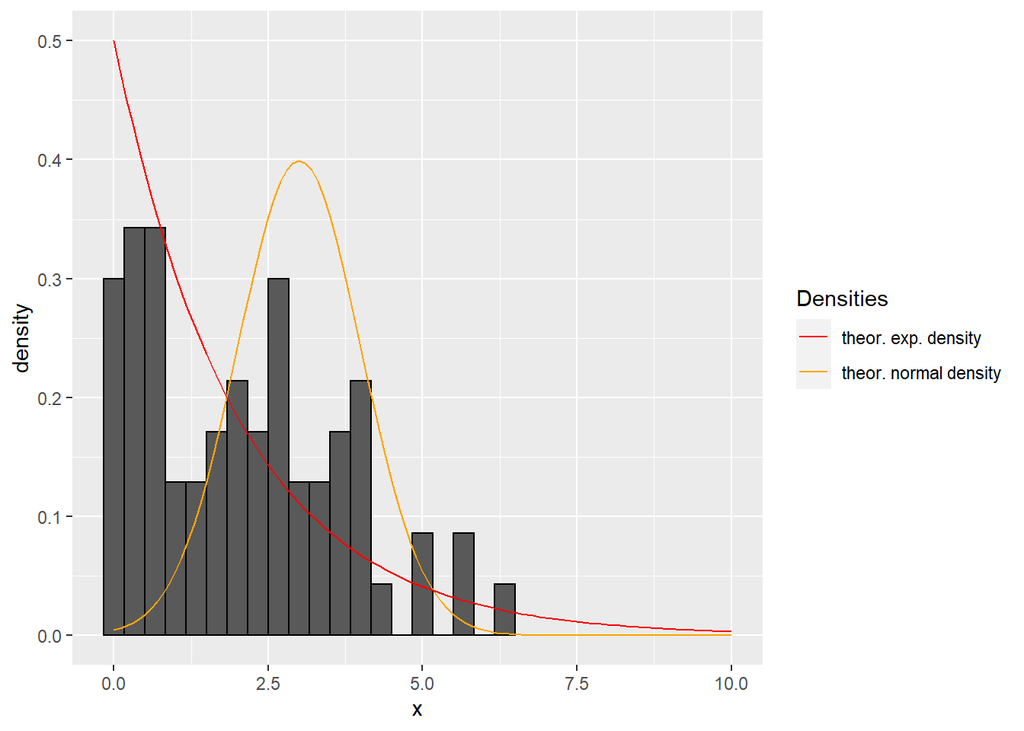

```r
s.1 <- rexp(50, 0.5)                  # sample 1
s.2 <- rnorm(20, 3, 1)                # sample 2
s <- c(s.1, s.2)                      # combined sample
dat <- tibble(x = s)                  # tibble

col.vec <- c("theor. exp. density" = "red", "theor. normal density" = "orange", "est. density" = "blue") # set color vector
ggplot(dat , aes(x = x)) +              # set up plot
geom_histogram(binwidth = 1/3, aes(y=..density..), colour="black") + # plot density histogram, default is frequency
  stat_function(fun = dnorm, args = list(mean = 3, sd = 1), mapping = aes(colour = "theor. normal density"), xlim = c(0, 10)) +  # add theoretical norm density
  stat_function(fun = dexp, args = list(rate = 0.5), mapping = aes(colour = "theor. exp. density"), xlim = c(0, 10)) +  # add theoretical density
  scale_colour_manual(name="Densities",values = col.vec) + # define legend structure
  theme(legend.position = "right")                         # add legend
## Warning: `mapping` is not used by stat_function()
```

11. Plot the standard exponential distribution, mark 95%-quantile and highlight the area under the density curve beyond the 95%-quantile.

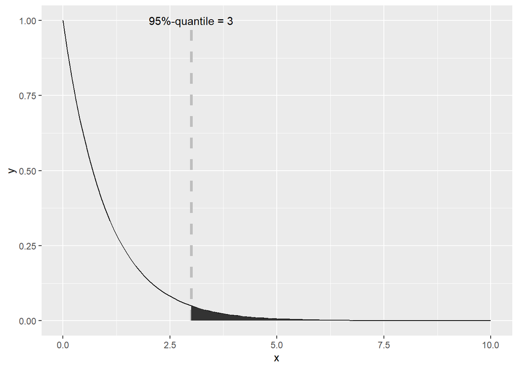

```r
q95 <- qexp(0.95)
ggplot(data = data.frame(x = 0:10) , aes(x = x)) +              # set up plot
  stat_function(fun = dexp, args = list(rate = 1)) +           # add density
  geom_segment(aes(x = q95, y = 0, xend = q95, yend = 1), size = 1.25, color = "grey", linetype ="dashed") + # add vertical line
  stat_function(fun = dexp, args = list(rate = 1), xlim = c(q95, 10),  geom = "area") + # add 5%-area
  annotate(geom="text", x=q95, y=1, label=paste("95%-quantile =", round(q95,2)))              # annotate 95%-quantile
```

-> postponed